# Possible factors that affect aiming speed

## Introduction

In my project 2 I decided to explore whether or not hunger had an effect on the speed in which I could complete the HumanBenchmark aim speed test, where you have to click on 30 targets as quickly as possible. For this project I decided to explore whether other factors such as the time of day, location the test was taken, and amount of sleep as well as hunger also played a part in my aim speed. I collected my data through observational logging on a Google form. I recorded my data using the same structure as project 2 where I would fill out the form within 30 minutes before having something to eat and within 30 minutes after eating.

## Hunger and Aim performance

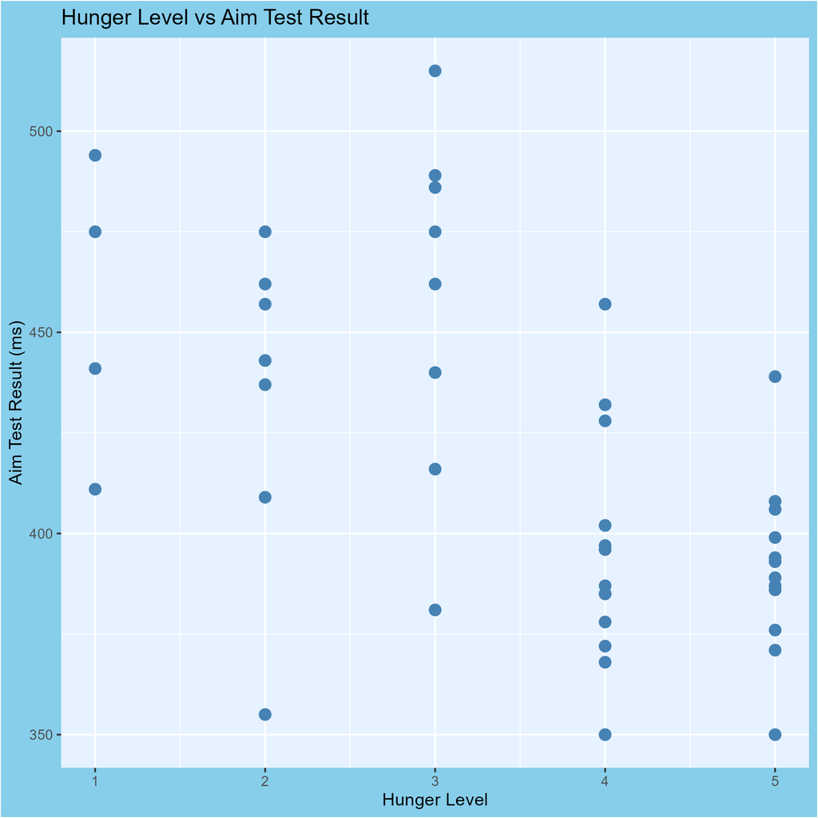

Scatterplot showing the relationship of hunger level and aim speed. The hungrier I tended to be, the worse my aim speed.

This visualization shows the relationship between hunger level and aim speed in milliseconds (ms). The hunger level is measured from 1-5 where 1 is very hungry and 5 is not hungry at all. The data suggests that reaction speed can be quite variable across all of the hunger levels, however it is clear that the times taken to complete the aim speed test tend to be lower for the 4 and 5 hunger levels. This means that I tended to perform better on the aim speed test when I was less hungry, confirming my findings in project 2.